# Math 656 HW1

Jeff Gould

8/29/2020

First, load the two wine data sets and merge:

```r
red_wine <- foreign::read.arff("winequality-red.arff") %>%
  mutate(wine = "red")

white_wine <- foreign::read.arff("winequality-white.arff") %>%
  mutate(wine = "white")

wine_all <- bind_rows(red_wine, white_wine)
```

First I look at the distribution of residual sugar for red and white wine. White wine tends to be sweeter than red, so I expected to see a higher amount of sugar. Sure enough, this was the case. I plot the box plot and the density for each:

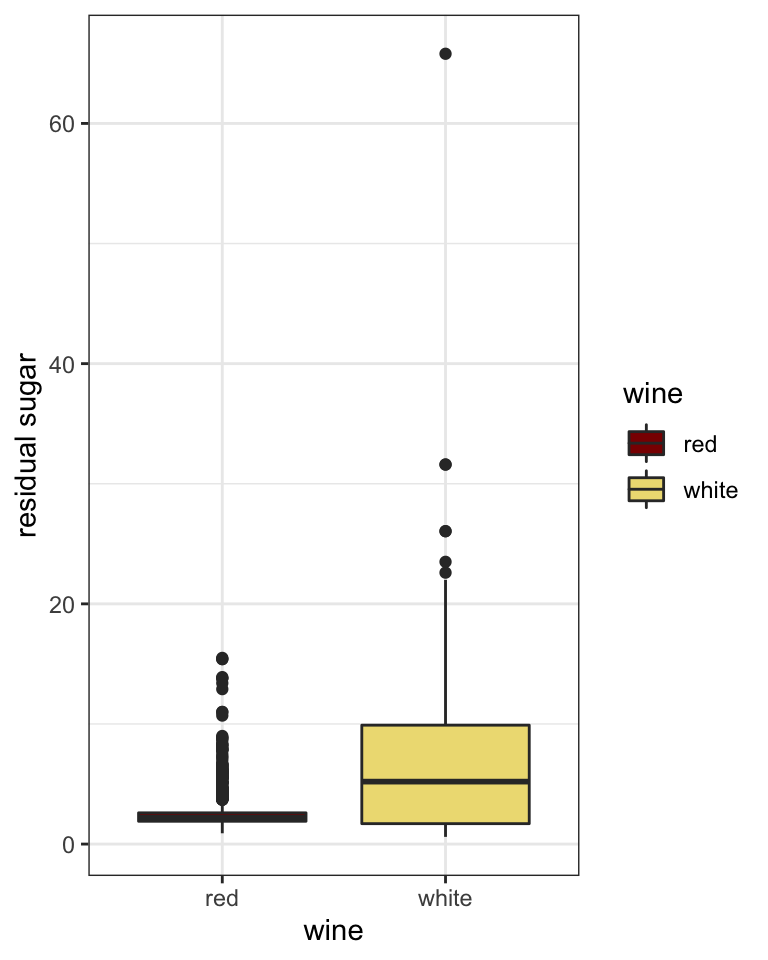

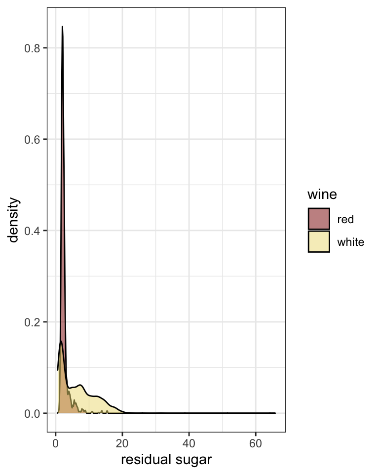

```r
box <- ggplot(data = wine_all) +
  geom_boxplot(aes(x = wine, y = `residual sugar`, fill = wine)) +
  theme_bw() +
  scale_fill_manual(values = c("red4", "lightgoldenrod"))

density_plot <- ggplot(data = wine_all) +
  geom_density(aes(x = `residual sugar`, fill = wine), alpha = 0.5) +
  theme_bw() +
  scale_fill_manual(values = c("red4", "lightgoldenrod"))
```

We see that this is the case. Red wines have a much narrower distribution of residual sugar compared to their white counterparts, and see that white wines usually have much more sugar. There are also a few outlier values for the white wine, which I found made some subsequent plots tough to read. So I winsorized the residual sugar tail to account for this

```r
white_wine$`residual sugar` = DescTools::Winsorize(white_wine$`residual sugar`, probs = c(0,.995))
wine_all <- bind_rows(red_wine, white_wine)
```

Here we have matrix plots of the relationships between residual sugar, free sulfur dioxide, density, pH, and alcohol

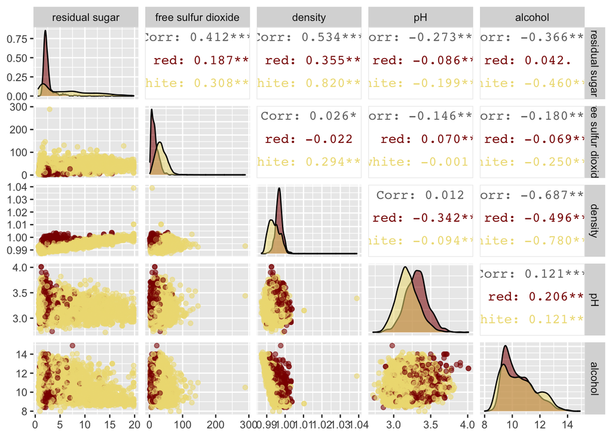

```r
# ggplot(data = red_wine, aes(y = alcohol, x = `residual sugar`, color = wine)) +
#   geom_point() +
#   theme_bw()
#
# ggplot(data = wine_all, aes(x = `residual sugar`)) +
#   geom_density(aes(color = wine, fill = wine), alpha = 0.5) +
#   theme_bw() +
#   scale_x_continuous(limits = c(0,20))

GGally::ggpairs(wine_all[sample(c(1:nrow(wine_all)), size = nrow(wine_all)),], columns = c(4,6, 8,9,11), aes(alpha = 0.05, color = wine)) +
  scale_fill_manual(values = c("red4", "lightgoldenrod")) +
  scale_color_manual(values = c("red4", "lightgoldenrod"))
```

We again see the outliers at white wine in regards to density and free sulfur dioxide, and looking at the graphs we see that most of those are the same wines the we winsorized residual sugar for. However I don’t want to overclean the data for this elementary analysis.